# RegulationIndex Tutorial 2: Calculating regulation index for multiple samples of one cell type

# Introduction

To better distinguish between the gene regulatory states, we introduce a gene-specific statistic, ‘k-proportion’. This is the percentage of cells with gene expression less than a defined integer value, k, which is determined based on the mean gene expression count. Consider a situation where certain genes exhibit high expression levels in a limited subset of cells. This extreme expression skews the overall average upward, however the k-proportions (a measure reflecting the portion of cells with considerably lower expression) remain high. Essentially, under equivalent mean expressions, regulatory genes display significantly higher values of k-proportions compared to their homeostatic counterparts.

To install the `RegulationIndex` and other packages used in the tutorial, you can use the following code.

```r
install.packages(c("umap", "viridis", "Seurat"))
BiocManager::install(c("org.Hs.eg.db", "ComplexHeatmap", "clusterProfiler", "ExperimentHub", "scater", "muscat"))

library(devtools)
devtools::install_github("ChenMengjie/RegulationIndex")
```

Then load the following libraries used in this tutorial:

```r
# Load the libraries used in this tutorial
library(RegulationIndex)
library(ComplexHeatmap)
library(viridis)
library(Seurat)
library(umap)
library(clusterProfiler)
library(org.Hs.eg.db)
library(ggplot2)
library(ExperimentHub)
library(scater)
library(muscat)
```

# Dataset 2: B cells under IFN-β stimulation.

In this case study, we applied our framework to data collected by Kang et al. This dataset consists of cells from eight distinct cell types, collected from peripheral blood mononuclear cells of 8 lupus patients. We performed quality control on the original data and retained 7,661 genes for further analysis. We will demonstrate the inflation test on 2,880 B cells as an example. Within B cells, the cells are evenly split into two groups for perturbation: IFN-β stimulated and un-stimulated control.

```r
# Access the ExperimentHub and retrieve the Kang dataset
eh = ExperimentHub()
query(eh, "Kang")
```

```
## ExperimentHub with 3 records
## # snapshotDate(): 2023-10-24
## # $dataprovider: NCI_GDC, GEO
## # $species: Homo sapiens
## # $rdataclass: character, SingleCellExperiment, BSseq
## # additional mcols(): taxonomyid, genome, description,
## #   coordinate_1_based, maintainer, rdatadateadded, preparerclass, tags,
## #   rdatapath, sourceurl, sourcetype
## # retrieve records with, e.g., 'object[["EH1661"]]'
##
##            title
##   EH1661 | Whole Genome Bisulfit Sequencing Data for 47 samples
##   EH1662 | Whole Genome Bisulfit Sequencing Data for 47 samples
##   EH2259 | Kang18_8vs8
```

```r
sce = eh[["EH2259"]]
```

```
## see ?muscData and browseVignettes('muscData') for documentation
```

```
## loading from cache
```

```r
# remove undetected genes
sce <- sce[rowSums(counts(sce) > 0) > 0, ]

# remove lowly expressed genes
sce <- sce[rowSums(counts(sce) > 1) >= 10, ]
dim(sce)
```

```
## [1]  7661 29065
```

```r
# Create a unique identifier for samples
sce$id <- paste0(sce$stim, sce$ind)
(sce <- prepSCE(sce,
    kid = "cell", # subpopulation assignments
    gid = "stim",  # group IDs (ctrl/stim)
    sid = "id",   # sample IDs (ctrl/stim.1234)
    drop = FALSE) ) # drop all other colData columns
```

```
## class: SingleCellExperiment
## dim: 7661 29065
## metadata(1): experiment_info
## assays(1): counts
## rownames(7661): NOC2L HES4 ... S100B PRMT2
## rowData names(2): ENSEMBL SYMBOL
## colnames(29065): AAACATACAATGCC-1 AAACATACATTTCC-1 ... TTTGCATGGTTTGG-1
##   TTTGCATGTCTTAC-1
## colData names(6): cluster_id sample_id ... cluster multiplets
## reducedDimNames(1): TSNE
## mainExpName: NULL
## altExpNames(0):
```

```r
counts <- sce@assays@data@listData[["counts"]][, sce@colData@listData$cluster_id %in% "B cells"]
sample_id <- sce@colData@listData$sample_id[sce@colData@listData$cluster_id  %in%  "B cells"]

dim(counts)
```

```
## [1] 7661 2880
```

```r
length(sample_id)
```

```
## [1] 2880
```

```r
table(sample_id)
```

```
## sample_id
##  ctrl101 ctrl1015 ctrl1016 ctrl1039  ctrl107 ctrl1244 ctrl1256 ctrl1488
##      119      495      150       32       52      143      250      247
##  stim101 stim1015 stim1016 stim1039  stim107 stim1244 stim1256 stim1488
##      151      369      133       49       60      104      223      303
```

We applied the k-proportion inflation test on UMI counts for each of 16 samples (8 donors x 2 treatment conditions), respectively, by calling the main function `Kprop_inflation_test()` and providing the sample information through option `grouping`.

```r
cluster.zscore.summary <- Kprop_inflation_test(counts, grouping = sample_id, min.depth.group = 500, cell.depth.ranges = c(500, 10000), genemean.cutoff = 0.5, filter.gene = FALSE)
```

You can visualize the k-proportions from any sample using a waveplot. Here we make a waveplot for the fifth sample.

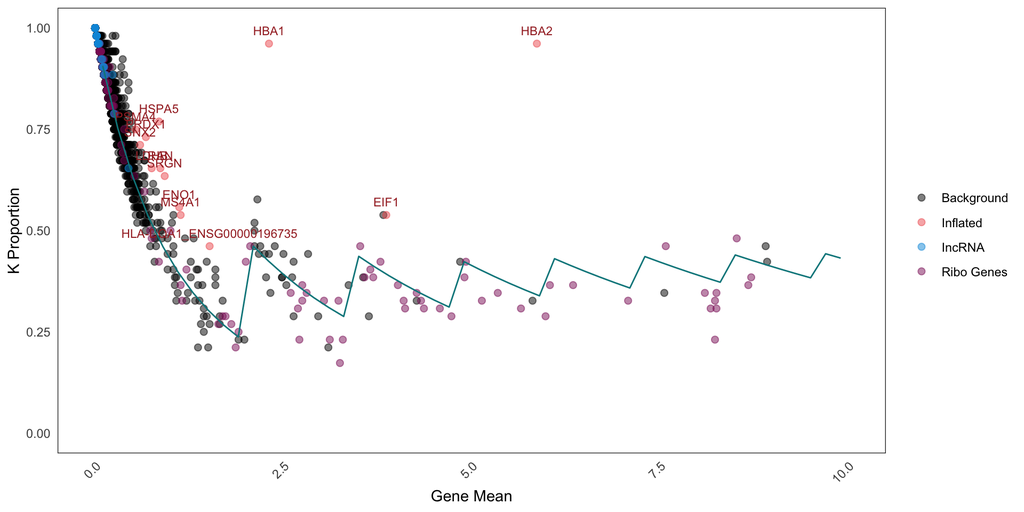

```r
wave_one <- waveplot(cluster.zscore.summary[[5]], show_mean_cutoff = 0.5, xmax = 10)
wave_one
```

Next, let’s identify genes that are inflated in at least two samples:

```r
sample.names <- names(table(sample_id))
all.inflated.genes <- NULL
for(i in 1:16){
  aa <- data.frame(id = sample.names[i], genes = rownames(cluster.zscore.summary[[i]]$Inflated))
  all.inflated.genes <- rbind(all.inflated.genes, aa)
}
gene.tab <- table(all.inflated.genes[,2])
selected.inflated.genes <- names(gene.tab)[which(gene.tab>1)]
length(selected.inflated.genes)
```

```
## [1] 101
```

There are 101 genes inflated in more than one sample, which is manageable for heatmap visualization. If the number is larger, consider adjusting your selection criteria according to your dataset, such as genes inflated in more than 5 or 10% of the samples. Now, let’s check the z-scores and means of selected inflated genes across all samples:

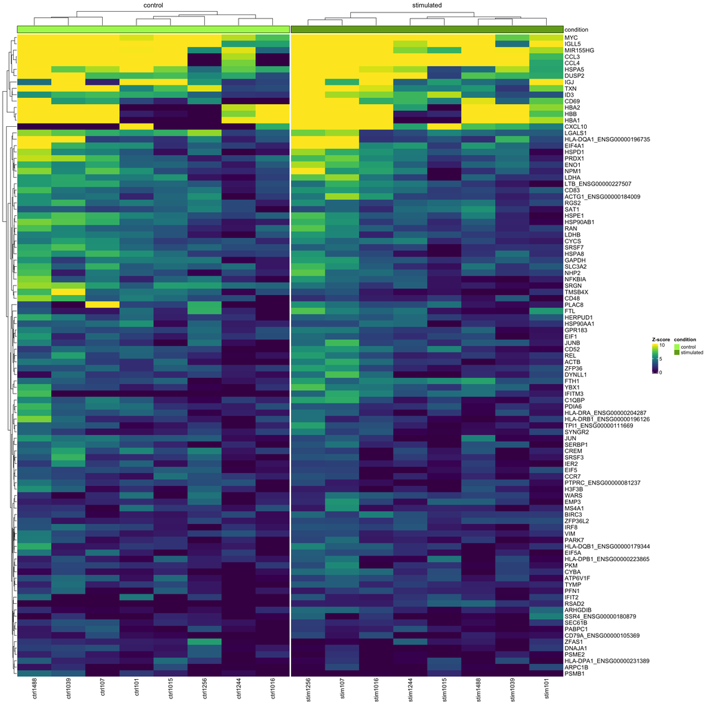

```r
all.zscore <- NULL
all.means <- NULL
for(j in 1:16){
  all.zscore <- cbind(all.zscore, cluster.zscore.summary[[j]]$Zscores[selected.inflated.genes, "zscore"])
  all.means <- cbind(all.means, cluster.zscore.summary[[j]]$Zscores[selected.inflated.genes, "gene_mean"])
}
colnames(all.zscore) <- colnames(all.means) <- unique(sample_id)
rownames(all.zscore) <- rownames(all.means) <- selected.inflated.genes

all.zscore[is.na(all.zscore)] <- 0
all.zscore[all.zscore < 0] <- 0
all.zscore[all.zscore > 10] <- 10

Colors <- viridis(40)

condition <-  c(rep("control", 8), rep("stimulated", 8))
ha = HeatmapAnnotation(
  condition = condition,
  border = TRUE)

Heatmap(all.zscore, name = "Z-score", column_split = condition,
        cluster_column_slices = FALSE, col=Colors, top_annotation = ha)
```

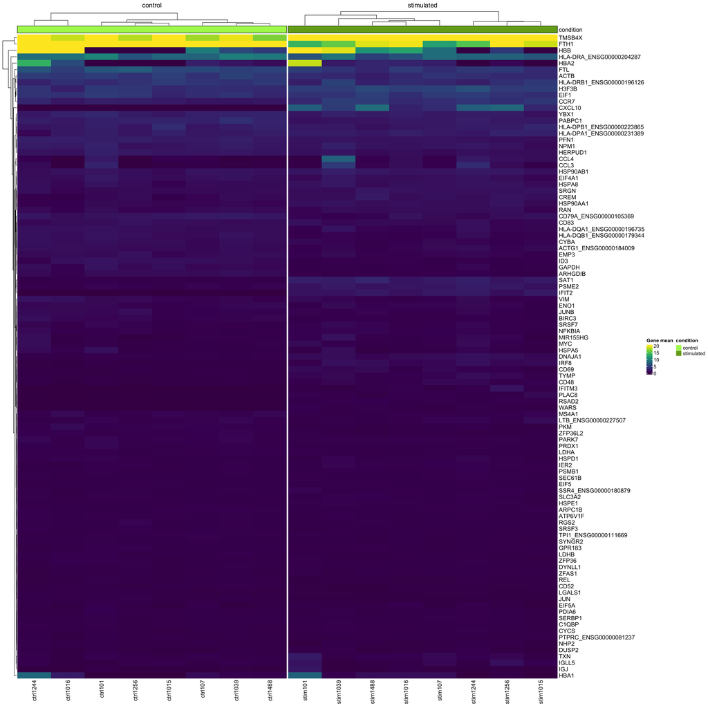

```r
all.means[all.means > 20] <- 20

Heatmap(all.means, name = "Gene mean", column_split = condition,
        cluster_column_slices = FALSE, col=Colors, top_annotation = ha)
```

We can perform enrichment analysis for genes that are sharply up-regulated in a subset.

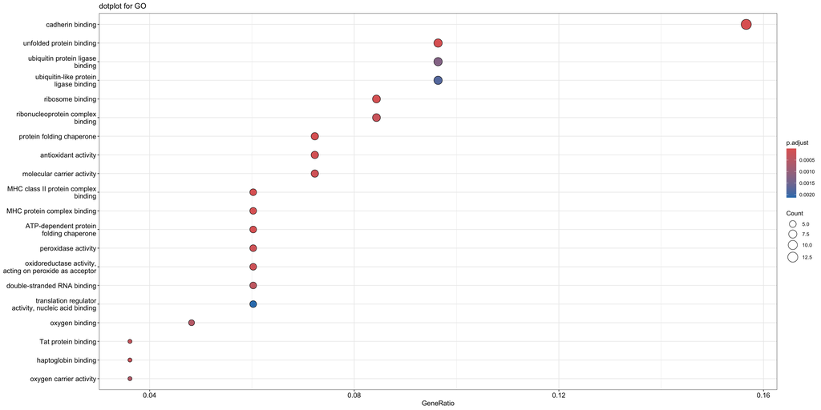

```r
# List of gene names
geneList <- selected.inflated.genes

# Perform GO enrichment analysis using default settings
enrich_result <- enrichGO(gene = geneList, OrgDb = org.Hs.eg.db, keyType = "SYMBOL")

dotplot(enrich_result, showCategory=20) + ggtitle("dotplot for GO")
```

We are particularly interested in inflammation regulated genes. Below we display the UMI counts across all cells for a subset of inflated genes.

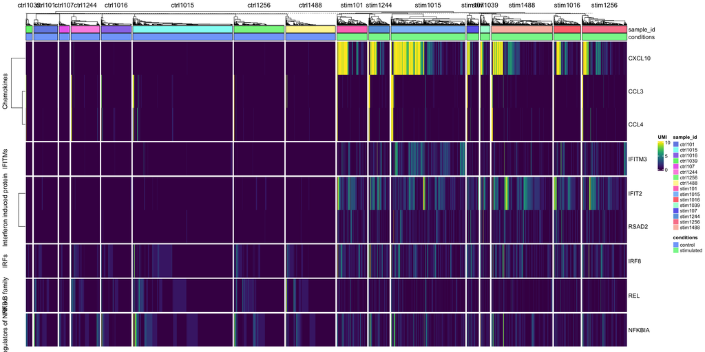

```r
subcounts <- counts[selected.inflated.genes, ]
subcounts[subcounts > 10] <- 10 # Cap values for visualization

# Convert the subset to a matrix
subcounts <- as.matrix(subcounts)

conditions <- rep("control", length(sample_id))
conditions[grep("stim", sample_id)] <- "stimulated"


ha = HeatmapAnnotation(
  sample_id = sample_id,
  conditions = conditions,
  border = TRUE)


# Define a subset of genes for visualization
subsetIDs <- c("CCL3", "CCL4", "CXCL10", "IFIT2", "IFITM3", "IRF8", "NFKBIA", "REL", "RSAD2")
subset_mat <- as.matrix(subcounts[subsetIDs, ])

# Define annotations for the subset genes
subset_gene_anno <- c("Chemokines", "Chemokines", "Chemokines", "Interferon induced protein", "IFITMs", "IRFs", "Regulators of NFKB", "NF-kB family", "Interferon induced protein")


Heatmap(subset_mat, name = "UMI", row_split = factor(subset_gene_anno), column_split = sample_id,
        cluster_row_slices = FALSE, col=Colors, top_annotation = ha, column_labels = rep("", ncol(subset_mat)))
```